# Two sample t test

Explaining the Two sample t test and how to run it in R

Author

Affiliations

Tendai Gwanzura & Ana Bravo

Florida International University

Robert Stempel College of Public Health and Social Work

Published

May 10, 2024

# Two sample t test

This is also called the independent sample *t* test. It is used to see whether the unknown population means of two groups are equal or different. This test requires one variable which can be the exposure *x* and another variable which can be the outcome *y*. If you have more than two groups then analysis of variance *(ANOVA)* will be more suitable. If data is nonparametric then an alternative test to use would be the *Mann Whitney U test* or a *permutation test*.(**cressie1986?**).

There are two types of t tests, the first being the **Student’s t test,** which assumes the variance of the two groups is equal, the second being the **Welch’s t test** (default in R), which assumes the variance in the two groups is different.

In this article we will be discussing the **Student’s t test**.

## Assumptions

- Measurements for one observation do not affect measurements for any other observation (assumes independence).
- Data in each group must be obtained via a random sample from the population.
- Data in each group are normally distributed.
- Data values are continuous.
- The variances for the two independent groups are equal in the **Student’s t test**.
- There should be no significant outliers.

## Hypotheses

1. $(H_0)$: the mean of group A $(m_A)$ is equal to the mean of group B $(m_B)$- two tailed test,
2. $(H_0)$: $(m_A)\ge (m_B)$- one tailed test.
3. $(H_0)$: $(m_A)\le (m_B)$- one tailed test.

   The corresponding alternative hypotheses would be as follows:
1. $(H_1)$: $(m_A)\neq(m_B)$- two tailed test.
2. $(H_1)$: $(m_A)<(m_B)$- one tailed test.
3. $(H_1)$: $(m_A)> (m_B)$- one tailed test.

## Statistical hypotheses formula

For the **Student’s t test** which assumes equal variance the following is how the |t| statistic may be calculated using groups A and B as examples:

$t ={ {m_{A} - m_{B}} \over \sqrt{ {S^2 \over n_{A} } + {S^2 \over n_{B}} }}$

This can be described as the sample mean difference divided by the sample standard deviation of the sample mean difference where:

$m_A$ and $m_B$ are the mean values of A and B,

$n_A$ and $n_B$ are the seize of group A and B,

$S^2$ is the estimator for the pooled variance,

with the degrees of freedom (*df)* = $n_A + n_B - 2$,

and $S^2$ is calculated as follows:

$S^2 = { {\sum{ (x_A-m_{A})^2} + \sum{ (x_B-m_{B})^2}} \over {n_{A} + n_{B} - 2 }}$

Results for both **Students t test** and **Welch’s t test** are usually similar unless the group sizes and standard deviations are different.

**What if the data is not independent?**

If the data is not independent such as paired data in the form of matched pairs which are correlated, we use the *paired t test*. This test checks whether the means of two paired groups are different from each other. It’s usually used in clinical trial studies with a “before and after” or case control studies with matched pairs. For this test we only assume the difference of each pair to be normally distributed (the paired groups are the ones important for analysis) unlike the *independent t test* which assumes that data from both samples are independent and variances are equal.(**fralick?**)

## Example

### Prerequisites

1. `tidyverse`: data manipulation and visualization.
2. `rstatix`: providing pipe friendly R functions for easy statistical analyses.
3. `car`: providing variance tests.

```r
#install.packages("ggstatplot")
#install.packages("car")
#install.packages("rstatix")
#install.packages(tidyVerse)
```

### Dataset

This example dataset sourced from [kaggle](https://www.kaggle.com/datasets/uciml/student-alcohol-consumption/versions/2?resource=download) was obtained from surveys of students in Math and Portuguese classes in secondary school. It contains demographic information on gender, social and study information.(**cortez2008?**)

```r
# load relevant libraries
library(rcompanion)
library(car)
library (gt)
library(gtsummary)
library(ggpubr)
library(rstatix)
library(tidyverse)
```

```r
# load the dataset
stu_math <- read_csv("../data/03_student-mat.csv")
```

**Checking the data**

```r
# check the data
glimpse(stu_math)
```

```
Rows: 395
Columns: 33
$ school     <chr> "GP", "GP", "GP", "GP", "GP", "GP", "GP", "GP", "GP", "GP",…
$ sex        <chr> "F", "F", "F", "F", "F", "M", "M", "F", "M", "M", "F", "F",…
$ age        <dbl> 18, 17, 15, 15, 16, 16, 16, 17, 15, 15, 15, 15, 15, 15, 15,…
$ address    <chr> "U", "U", "U", "U", "U", "U", "U", "U", "U", "U", "U", "U",…
$ famsize    <chr> "GT3", "GT3", "LE3", "GT3", "GT3", "LE3", "LE3", "GT3", "LE…
$ Pstatus    <chr> "A", "T", "T", "T", "T", "T", "T", "A", "A", "T", "T", "T",…
$ Medu       <dbl> 4, 1, 1, 4, 3, 4, 2, 4, 3, 3, 4, 2, 4, 4, 2, 4, 4, 3, 3, 4,…
$ Fedu       <dbl> 4, 1, 1, 2, 3, 3, 2, 4, 2, 4, 4, 1, 4, 3, 2, 4, 4, 3, 2, 3,…
$ Mjob       <chr> "at_home", "at_home", "at_home", "health", "other", "servic…
$ Fjob       <chr> "teacher", "other", "other", "services", "other", "other", …
$ reason     <chr> "course", "course", "other", "home", "home", "reputation", …
$ guardian   <chr> "mother", "father", "mother", "mother", "father", "mother",…
$ traveltime <dbl> 2, 1, 1, 1, 1, 1, 1, 2, 1, 1, 1, 3, 1, 2, 1, 1, 1, 3, 1, 1,…
```

[output cut: 20 more lines]

In total there are 395 observations and 33 variables. We will drop the variables we do not need and keep the variables that will help us answer the following: **Is there a difference between boys and girls in math final grades?**

$H_0$: There is no statistical difference between the final grades between boys and girls.

$H_1$: There is a statistically significant difference in the final grades between the two groups.

```r
# creating a subset of the data
math = subset(stu_math, select= c(sex,G3))
glimpse(math)
```

```
Rows: 395
Columns: 2
$ sex <chr> "F", "F", "F", "F", "F", "M", "M", "F", "M", "M", "F", "F", "M", "…
$ G3  <dbl> 6, 6, 10, 15, 10, 15, 11, 6, 19, 15, 9, 12, 14, 11, 16, 14, 14, 10…
```

**Summary statistics**- the dependent variable is continuous *(grades=G3)* and the independent variable is character but binary *(sex)*.

```r
# summarizing our data
 summary(math)
```

```
     sex                  G3
 Length:395         Min.   : 0.00
 Class :character   1st Qu.: 8.00
 Mode  :character   Median :11.00
                    Mean   :10.42
                    3rd Qu.:14.00
                    Max.   :20.00
```

We see that data ranges from 0-20 with 0 being people who were absent and could not take the test therefore missing data. We remove these 0 values before running the t test. However other models should be considered such as the zero inflated model to differentiate those who truly got a 0 and those who were not present to take test.

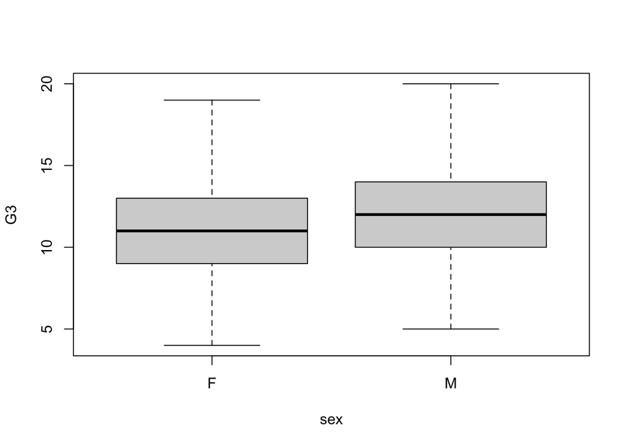

```r
# creating a boxplot to visualize the data with no outliers
math2 = subset(math, G3>0)
boxplot(G3 ~ sex,data=math2)
```

**Visualizing the data**- we can use histograms and box lots to visualize the data to check for outliers and distribution thus checking for normality.

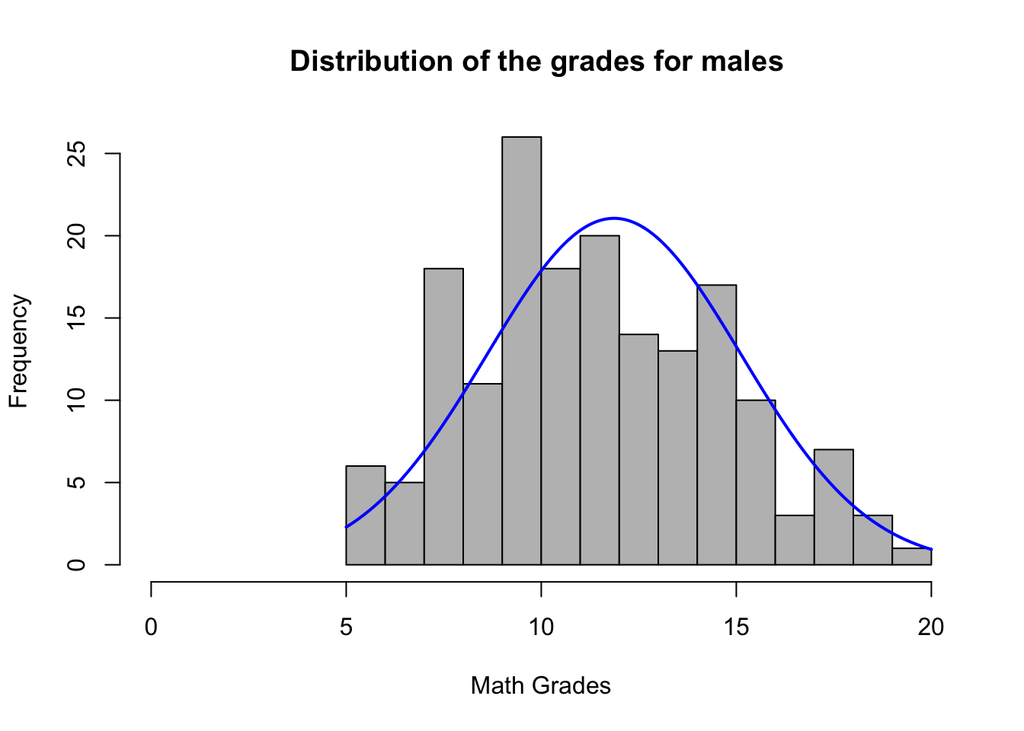

```r
# Histograms for data by groups

male = math2$G3[math2$sex == "M"]
female = math2$G3[math2$sex == "F"]

# plotting distribution for males
plotNormalHistogram(
  male,
  breaks= 20,
  xlim=c(0,20),
  main="Distribution of the grades for males ",
  xlab= "Math Grades"
  )
```

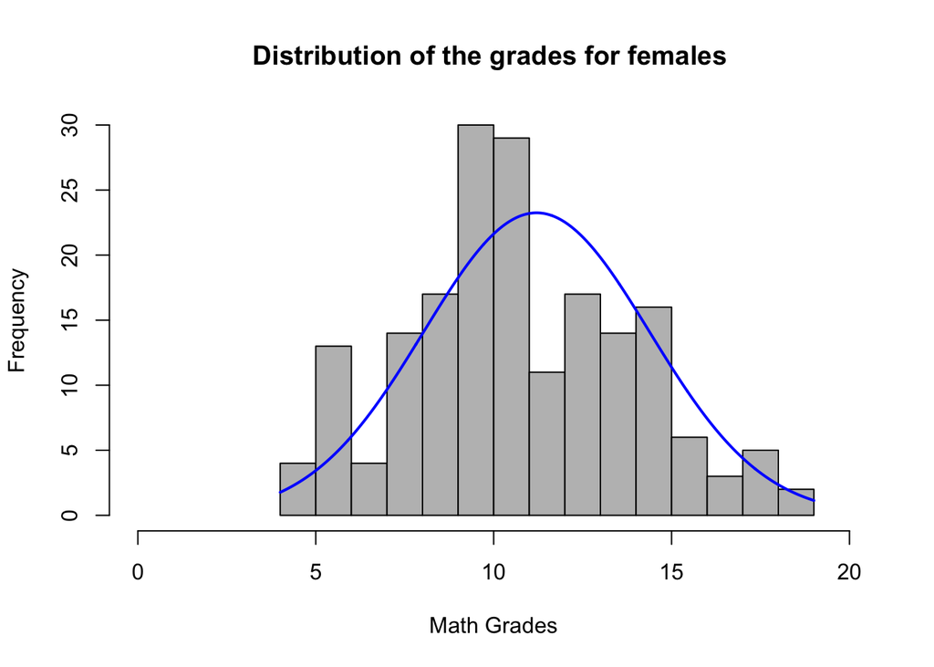

```r
# plotting distribution for females
plotNormalHistogram(
  female, breaks= 20,
  xlim=c(0,20),
  main="Distribution of the grades for females ",
  xlab= "Math Grades"
  )
```

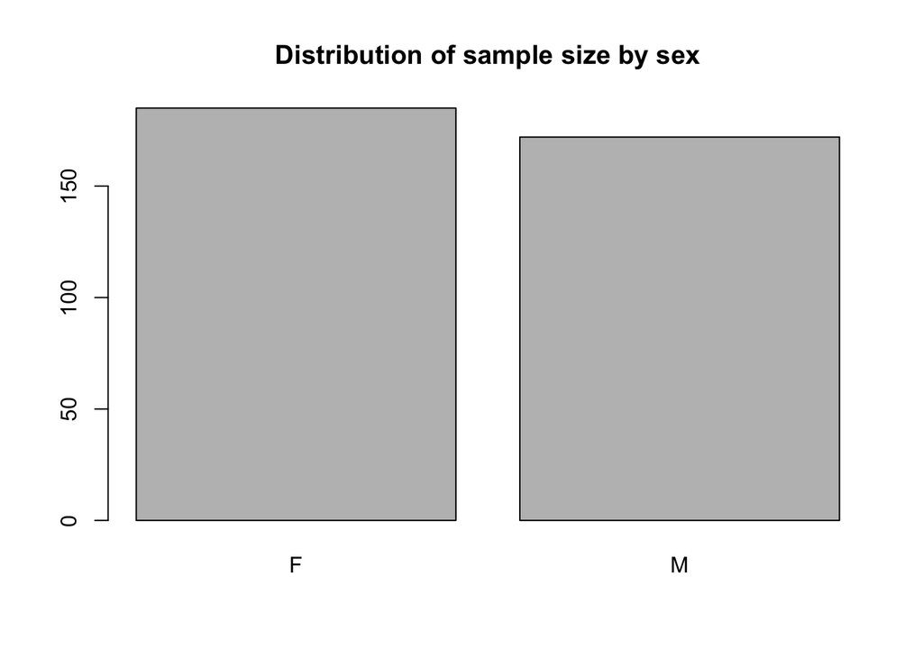

```r
# plotting bar plot to see the distribution in sample size
sample_size = table(math2$sex)
barplot(sample_size,main= "Distribution of sample size by sex")
```

The bar graph shows that there are slightly more females in the sample than males.

**Identifying outliers**

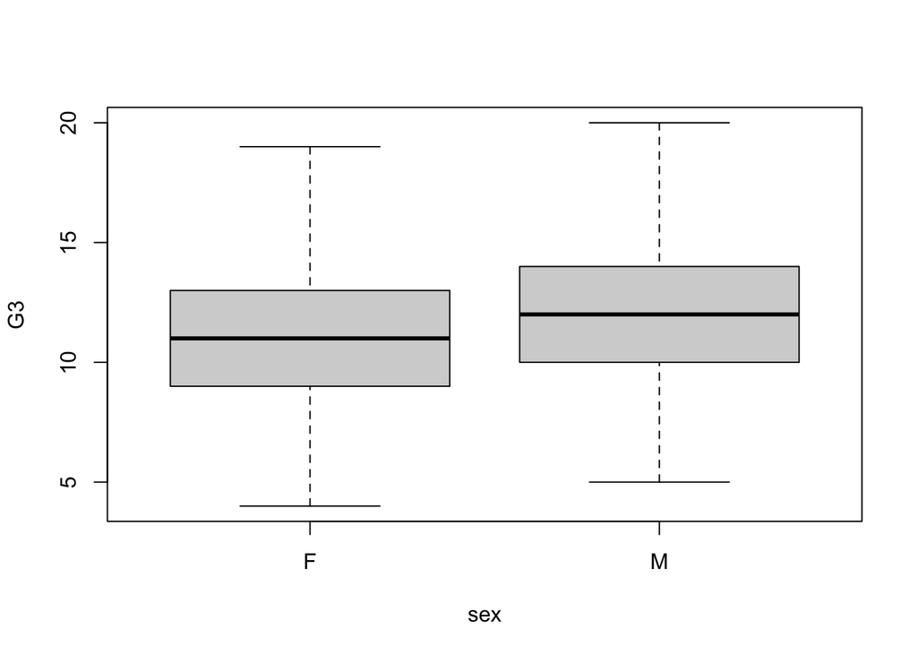

```r
# creating a boxplot to visualize the outliers (G3=0)
boxplot(G3 ~ sex,data=math2)
```

The box plot shows us that there are no outliers as these have been removed in terms of people who had a score of 0. This score is not truly reflective of the performance between boys and girls as a grade of 0 may represent absentia or other reasons for the test not been taken. Therefore we opt to drop the outliers. We will compare to see if this decision affects the mean which appears similar from the above plot.

```r
# finding the mean for the groups with outliers
mean(math$G3[math$sex=="F"])
```

```
[1] 9.966346
```

```r
mean(math$G3[math$sex=="M"])
```

```
[1] 10.91444
```

```r
# finding the mean for the groups without outliers
mean(math2$G3[math2$sex=="F"])
```

```
[1] 11.20541
```

```r
mean(math2$G3[math2$sex=="M"])
```

```
[1] 11.86628
```

The mean has increased slightly and the difference decreased after removing the outliers but the distribution is still the same.

**Check the equality of variances (homogeneity)**

Other tests include *F test 2 sided*, *Brown-Forsythe* and *O’Brien* but we shall not cover these.

```r
# running the Bartlett's test to check equal variance
bartlett.test(G3~sex, data=math2)
```

```
    Bartlett test of homogeneity of variances

data:  G3 by sex
Bartlett's K-squared = 0.12148, df = 1, p-value = 0.7274
```

```r
# running the Levene's test to check equal variance
math2 %>% levene_test(G3~sex)
```

```
# A tibble: 1 × 4
    df1   df2 statistic     p
  <int> <int>     <dbl> <dbl>
1     1   355     0.614 0.434
```

The p value is greater than 0.05 suggesting there is no difference between the variances of the two groups.

### Assessment

1. Data is continuous(G3)
2. Data is normally distributed
3. Data is independent (males and females distinct not the same individual)
4. No significant outliers
5. There are equal variances

As the assumptions are met we go ahead to perform the **Student’s t test**.

### **Performing the two-sample *t*-test**

Since the default is the **Welch t test** we use the $\color{blue}{\text{var.eqaul = TRUE }}$ code to signify a **Student’s t test**. There is a `t.test()` function in `stats` package and a `t_test()` in the `rstatix` package. For this analysis we use the `rstatix` method as it comes out as a table.

```r
# perfoming the two sample t test
stat.test <- math2 %>%
  t_test(G3~ sex, var.equal=TRUE) %>%
  add_significance()
stat.test
```

```
# A tibble: 1 × 9
  .y.   group1 group2    n1    n2 statistic    df      p p.signif
  <chr> <chr>  <chr>  <int> <int>     <dbl> <dbl>  <dbl> <chr>
1 G3    F      M        185   172     -1.94   355 0.0531 ns
```

```r
stat.test$statistic
```

```
        t
-1.940477
```

The results are represented as follows;

- **y** - dependent variable
- **group1, group 2** - compared groups(independent variables)
- **df** - degrees of freedom
- **p** - p value

`gtsummary` table of results

```r
 math2 |>
  tbl_summary(
    by = sex,
    statistic =
      list(
        all_continuous() ~ "{mean} ({sd})",
        all_dichotomous() ~ "{p}%")
    ) |>
   add_n() |>
  add_overall() |>
  add_difference()
```

| **Characteristic** | **N** | **Overall**, N = 357<sup>1</sup> | **F**, N = 185<sup>1</sup> | **M**, N = 172<sup>1</sup> | **Difference**<sup>2</sup> | **95% CI**<sup>2,3</sup> | **p-value**<sup>2</sup> |
| --- | --- | --- | --- | --- | --- | --- | --- |
| G3 | 357 | 11.5 (3.2) | 11.2 (3.2) | 11.9 (3.3) | -0.66 | -1.3, 0.01 | 0.053 |

<sup>1</sup> Mean (SD)  
<sup>2</sup> Welch Two Sample t-test  
<sup>3</sup> CI = Confidence Interval

**Interpretation of results**

For the two sample t test with t(355) = -1.940477, p = 0.0531, the p value is greater than our alpha of 0.05 , we fail to reject the null hypothesis and conclude that there is no statistical difference between the means of the two groups. There is no difference in final grades between boys and girls. *(A significant |t| would be 1.96 or greater).*

**Effect size**

*Cohen’s d* can be an used as an effect size statistic for the two sample t test. It is the difference between the means of each group divided by the pooled standard deviation.

$d= {m_A-m_B \over SD_pooled}$

It ranges from 0 to infinity, with 0 indicating no effect where the means are equal. 0.5 means that the means differ by half the standard deviation of the data and 1 means they differ by 1 standard deviation. It is divided into small, medium or large using the following cut off points.

- *small* 0.2-<0.5
- *medium* 0.5-<0.8
- *large* >=0.8

For the above test the following is how we can find the effect size;

```r
#perfoming cohen's d
math2 %>%
  cohens_d(G3~sex,var.equal = TRUE)
```

```
# A tibble: 1 × 7
  .y.   group1 group2 effsize    n1    n2 magnitude
* <chr> <chr>  <chr>    <dbl> <int> <int> <ord>
1 G3    F      M       -0.206   185   172 small
```

The effect size is *small* d= -0.20.

**What if it is one tailed t test?**

Use the $\color{blue}{\text{alternative =}}$ option to determine if one group is $\color{blue}{\text{"less"}}$ or $\color{blue}{\text{"greater"}}$. For example if we want to see whether the final grades for females are greater than males we can use the following code:

```r
# perfoming the one tailed two sample t test
stat.test <- math2 %>%
  t_test(G3~ sex, var.equal=TRUE, alternative = "greater") %>%
  add_significance()
stat.test
```

```
# A tibble: 1 × 9
  .y.   group1 group2    n1    n2 statistic    df     p p.signif
  <chr> <chr>  <chr>  <int> <int>     <dbl> <dbl> <dbl> <chr>
1 G3    F      M        185   172     -1.94   355 0.973 ns
```

The p value is greater than 0.05 (p=0.973), we fail to reject the null hypothesis. We conclude that the final grades for females are not significantly greater than for males.

**What about running the paired sample t test?**

We can simply add the syntax $\color{blue}{\text{paired= TRUE}}$ to our `t_test()` to run the analysis for matched pairs data.

## Conclusion

This article covers the **Student’s t test** and how we run it in R. It also shows how we find the effect size and how we can conclude the results.